# Кудряшов Александр, c4210, лабораторная по фундаментальному фиинансовому анализу в рамках курса "Инвестиционные стратегии на финансовых рынках"

# 0 План работы

1. Подсчитать основные показатели ПАО ГМК "Норильский Никель" на основе финансового отчета за квартал, чтобы разобраться и прочувствовать. Сопоставить с публично доступными подсчетами.
   - Официальные данные за 2018г [тут](https://www.nornickel.ru/investors/disclosure/financials/)
   - Разобраться в показателях EBIT, EBITDA, LTD, STD, EA, D, OCF, DIV, CL и проч. и их значении в теории
   - Понять разницу между отчетами по МФСО и РСБУ
2. Взять историю реальных показателей [отсюда, например](http://dividendo.ru/fundamentalnyy-analiz-gmk-norilskiy-nikel.html) и посмотреть их эффективность на [реальных данных](https://www.finam.ru/profile/moex-akcii/nornickel-gmk/export/)

## 1.1 Разница между разными видами отчетности

> Существует четыре главных формы финансовой отчётности:
> - *бухгалтерский баланс* группирует активы и пассивы компании в денежном выражении.
> - *отчёт о финансовых результатах* содержит данные о доходах, расходах и финансовых результатах в сумме нарастающим итогом с начала года до отчётной даты.
> - *отчёт об изменениях капитала* раскрывает информацию о движении уставного капитала, резервного капитала, дополнительного капитала, а также информацию об изменениях величины нераспределённой прибыли (непокрытого убытка) организации.
> - *отчёт о движении денежных средств* показывает разницу между притоком и оттоком денежных средств за определённый отчётный период.

## 1.2 Разница между отчетами по МФСО и РСБУ

> Согласно РСБУ, бухгалтерская отчётность компаний (для организаций кроме кредитных, страховых и бюджетных) состоит из следующих элементов:
> - бухгалтерский баланс
> - отчёт о прибылях и убытках
> - отчёт об изменениях капитала
> - отчёт о движении денежных средств
> - отчёт о целевом использовании полученных средств

Таким образом, получается, что отчет по форме РСБУ покрывает все основные формы финансовой отчетности. При этом все то же самое можно сказать про МФСО. В чем же разница? Гугл предлагает следующий [ответ](http://ppt.ru/art/buh-uchet/rsbu-msfo):

> МФСО -- демонстрация бухгалтерской и управленческой информации для кредиторов и инвесторов, РСБУ -- это контроль уполномоченных надзорных органов за ведением учета и составлением документации.

Так что ориентироваться надо на МФСО, но и ради любопытства сравнить цифры из МФСО и РСБУ тоже интересно было бы.

## 1.3 Разбираемся в показателях

Тут представлены не все возможные показатели, но остановиимся на этих.

*EBIT* -- earnings before interest and tax -- вся прибыль компании до уплаты налогов и дивидендов. **Сама по себе не показатель**.

*EBITDA* -- earnings before interest, tax, deprecation and amortization -- вся прибыль до уплаты налогов, дивидендов, потери стоимости с учетом времени (инфляции) и амортизационных издержек. **Тоже сама по себе не показатель**.

*EV* — enterprise value, Рыночная капитализация + Все долговые обязательства − Доступные денежные средства компании. **Сама по себе не показатель**.

*P/E* -- price to earnings, отношение цены компании к прибыли. Если точнее, рыночной цены акции к чистой прибыли на одну акцию. Или рыночной капитализации всей компании к годовой чистой прибыли.

Ресурс investopedia.com [утверждает](https://www.investopedia.com/terms/p/price-earningsratio.asp):

> P/E ratio for the S&P 500, which is a market index that represents trading in the broader stock market, was 15.3 in January 2013, which fell below the long-term average of nearly 19.0. This suggests that stocks were trading inexpensively during the month, according to a 2013 "USA Today" article. As a result, some of the stocks trading at a lower-than-average P/E could represent a buying opportunity that might lead to future profits.

Кроме того, чей-то блог на [ru.investing.com](https://ru.investing.com/analysis/%D0%9C%D0%BE%D0%B9-%D0%BC%D0%B5%D1%82%D0%BE%D0%B4-%D0%B0%D0%BD%D0%B0%D0%BB%D0%B8%D0%B7%D0%B0-%D0%B0%D0%BA%D1%86%D0%B8%D0%B9-94943):

> P/E = 15 говорит о справедливой оценке акции; P/E > 20 о ее дороговизне. Однако низкий Р/Е не всегда хорошо. Например, у цикличных компаний он - предвестник грядущего спада.

Данных по российскому рынку я не нашел, поэтому будем ориентироваться на американский и считать, что P/E < 15 -- это сигнал о неодоцененности рынком акции. **Это показатель, который можно использовать для оценки компании самой по себе, а не сравнительно с другими в отрасли.**

*P/S* -- price to sales, это отношение рыночной цены акции к выручке, приходящейся на одну акцию.

[Investopedia.com](https://www.investopedia.com/ask/answers/032515/what-considered-favorable-price-sales-ratio.asp):

> Price to sales (P/S) ratios between 1 and 2 are generally considered good, and ratios less than 1 are considered excellent.

**Это показатель, который можно использовать для оценки компании самой по себе, а не сравнительно с другими в отрасли.**

*P/BV* -- price to book, это отношение рыночной цены акции к стоимости активов, приходящихся на одну акцию.

[Investopedia.com](https://www.investopedia.com/ask/answers/010915/what-considered-good-price-book-ratio.asp):

> It is difficult to pinpoint a specific numeric value of a "good" price-to-book (P/B) ratio when determining if a stock is undervalued and therefore a good investment. Ratio analysis can vary by industry. A good P/B ratio for one industry might be a poor ratio for another.

**Этот показатель стоит рассматривать только относительно других в отрасли, поэтому здесь он не учитывается**

*EV/EBITDA* — это рыночная оценка единицы прибыли.

[Investopedia.com](https://www.investopedia.com/ask/answers/072715/what-considered-healthy-evebitda.asp):

> The enterprise-value-to-EBITDA ratio varies by industry. However, the EV/EBITDA for the S&P 500 has typically averaged from 11 to 14 over the last few years. As of the end of 2017, the average EV/EBITDA for the S&P was 12.75. As a general guideline, an EV/EBITDA value below 10 is commonly interpreted as healthy and above average by analysts and investors.

**Это показатель, который можно использовать для оценки компании самой по себе, а не сравнительно с другими в отрасли.**

*EPS* — это чистая прибыль на одну обыкновенную акцию. Измеряется как отношение прибыли на количество акций.

Штука полезная, но скорее в момент выбора акций для покупки, чем вообще. Если средства ограничены, количество акций, которое можно купить, тоже ограничено. При прочих равных в таком случае надо выбирать либо те, у которых *EPS* исторически стабильный, либо те, у которых он выше.

*ROE* -- это доходность акционерного капитала в процентах годовых, то есть рентабельность.

Чем больше, тем лучше. Будем считать, что показатель хорош, если он значительно выше инфляции, т.е. в условиях российского рынка больше 10%. **Это показатель, который можно использовать для оценки компании самой по себе, а не сравнительно с другими в отрасли.**

Таким образом, P/E, P/S, EV/EBITDA, ROE -- показатели эффективности кампании, которые будут использоваться в части 2 работы.

# 1 Подсчёт мультипликаторов для ПАО ГМК Норильский никель

Берём [отчёт](https://www.nornickel.ru/files/ru/results/ifrs/2018/IFRS-Rus-RUB-Consolidation-Reporting.pdf) по МФСО за полгода, закончившиеся 30.06.18. Из него:

Отчет о балансе

[output not shown]

# 2 Работа с реальными показателями фундаментального анализа

```python
import pandas as pd
import matplotlib.pyplot as plt
from matplotlib import gridspec
import numpy as np
```

```python
# считаем данные
indicatorsDollar, indicatorsRouble, multipliers = \
    pd.read_html("http://dividendo.ru/fundamentalnyy-analiz-gmk-norilskiy-nikel.html",
                 header=0,
                 decimal=',',
                 thousands = '**')
```

```python
# посмотрим, как они выглядят
indicatorsDollar.head(5)
```

|  | Показатели (МСФО), млн. $ | 2016 | 2015 | 2014 | 2013 | 2012 | 2011 | 2010 | 2009 | 2008 | 2007 |
| --- | --- | --- | --- | --- | --- | --- | --- | --- | --- | --- | --- |
| 0 | Денежные средства и эквиваленты | 3 301 | 4 054 | 2 793 | 1 621 | 1 037 | 1 627 | 5 405 | 3 632 | 1 995 | 4 008 |
| 1 | Активы | 16 457 | 13 371 | 13 149 | 18 781 | 20 974 | 18 912 | 23 909 | 22 760 | 20 823 | 35 696 |
| 2 | Долгосрочный долг | 8 585 | 7 734 | 6 174 | 6 325 | 4 065 | 3 860 | 3 238 | 3 893 | 6 912 | 7 441 |
| 3 | Кратксрочный долг | 3 976 | 3 376 | 2 182 | 2 706 | 3 969 | 3 830 | 2 697 | 4 112 | 2 126 | 6 434 |
| 4 | Выручка | 8 259 | 8 542 | 11 869 | 11 489 | 12 065 | 14 122 | 12 775 | 10 155 | 13 980 | 17 119 |

```python
indicatorsRouble.head(5)
```

|  | Показатели (МСФО), млрд. руб. | 2016 | 2015 | 2014 | 2013 | 2012 | 2011 | 2010 | 2009 | 2008 |
| --- | --- | --- | --- | --- | --- | --- | --- | --- | --- | --- |
| 0 | Денежные средства и эквиваленты | 221.3 | 247.1 | 107.3 | 51.6 | 32.2 | 52.4 | 164.7 | 109.8 | 58.6 |
| 1 | Активы | 1103.2 | 815.1 | 505.1 | 598.2 | 652.1 | 608.9 | 728.7 | 688.4 | 611.8 |
| 2 | Долгосрочный долг | 575.5 | 471.4 | 237.2 | 201.4 | 126.4 | 124.3 | 98.7 | 117.7 | 203.1 |
| 3 | Кратксрочный долг | 266.5 | 205.8 | 83.8 | 86.2 | 123.4 | 123.3 | 82.2 | 124.4 | 62.5 |
| 4 | Выручка | 501.0 | 622.6 | 667.7 | 376.0 | 366.4 | 415.0 | 388.0 | 322.1 | 347.5 |

```python
multipliers.head(5)
```

|  | Мультипликаторы | 2016 | 2015 | 2014 | 2013 | 2012 | 2011 | 2010 | 2009 | 2008 |
| --- | --- | --- | --- | --- | --- | --- | --- | --- | --- | --- |
| 0 | ROA, % | 15.7 | 2025.7 | 23.5 | 5.6 | 11.0 | 17.8 | 14.1 | 12.5 | -0.6 |
| 1 | ROE, % | 60.0 | 92.6 | 61.5 | 8.3 | 16.5 | 29.6 | 18.9 | 19.9 | -3.5 |
| 2 | ROS, % | 30.7 | 20.3 | 16.9 | 6.7 | 18.0 | 25.5 | 25.8 | 25.6 | -3.2 |
| 3 | P/E, ед. | 10.4 | 11.5 | 11.4 | 33.7 | 16.2 | 8.9 | 13.6 | 9.8 | -34.2 |
| 4 | P/S, ед. | 3.2 | 2.3 | 1.9 | 2.3 | 2.9 | 2.3 | 3.5 | 2.5 | 1.1 |

```python
# удобнее развернуть таблицы
indDol = pd.DataFrame(data = indicatorsDollar.iloc[:, 1:].T)
indDol.columns = indicatorsDollar.iloc[indicatorsDollar.index, 0].values
indDol.head(5)
```

|  | Денежные средства и эквиваленты | Активы | Долгосрочный долг | Кратксрочный долг | Выручка | Операционные расходы | EBIT (Операционная прибыль) | EBITDA | EBT (Прибыль до налогов) | Налог на прибыль | Доля меньшинства | Чистая прибыль * | Операционный денежный поток |
| --- | --- | --- | --- | --- | --- | --- | --- | --- | --- | --- | --- | --- | --- |
| 2016 | 3 301 | 16 457 | 8 585 | 3 976 | 8 259 | 4 978 | 3 281 | 3 838 | 3 276 | -745 | 5 | 2 536 | 3 492 |
| 2015 | 4 054 | 13 371 | 7 734 | 3 376 | 8 542 | 5 036 | 3 506 | 509 506 | 2 244 | -528 | 18 | 1 734 | 3 705 000 |
| 2014 | 2 793 | 13 149 | 6 174 | 2 182 | 11 869 | 7 123 | 4 746 | 5 551 | 2 660 | -660 | 3 | 2 003 | 5 947 |
| 2013 | 1 621 | 18 781 | 6 325 | 2 706 | 11 489 | 9 013 | 2 476 | 3 357 | 1 330 | -565 | 9 | 774 | 4 115 |
| 2012 | 1 037 | 20 974 | 4 065 | 3 969 | 12 065 | 8 201 | 3 864 | 4 653 | 3 143 | -1 000 | 27 | 2 170 | 3 434 |

```python
# удобнее развернуть таблицы
indRub = pd.DataFrame(data=indicatorsRouble.iloc[:, 1:].T)
indRub.columns = indicatorsRouble.iloc[indicatorsRouble.index, 0].values
indRub.drop(axis=1, columns=['Дополнительная информация'], inplace=True)
indRub.head(5)
```

|  | Денежные средства и эквиваленты | Активы | Долгосрочный долг | Кратксрочный долг | Выручка | Операционные расходы | EBIT (Операционная прибыль) | EBITDA | EBT (Прибыль до налогов) | Налог на прибыль | Доля меньшинства (minority interest) | Чистая прибыль * | Операционный денежный поток | Капитализация | Количество АО , шт. | Цена АО на конец года , руб. |
| --- | --- | --- | --- | --- | --- | --- | --- | --- | --- | --- | --- | --- | --- | --- | --- | --- |
| 2016 | 221.3 | 1103.2 | 575.5 | 266.5 | 501.0 | 302.0 | 199.0 | 232.8 | 198.7 | -45.2 | 0.3 | 153.8 | 211.8 | 1601.8 | 158245476.0 | 10122.0 |
| 2015 | 247.1 | 815.1 | 471.4 | 205.8 | 622.6 | 367.0 | 255.5 | 37134.2 | 163.5 | -38.5 | 1.3 | 126.4 | 270030.4 | 1447.9 | 158245476.0 | 9150.0 |
| 2014 | 107.3 | 505.1 | 237.2 | 83.8 | 667.7 | 400.7 | 267.0 | 312.3 | 149.6 | -37.1 | 0.2 | 112.7 | 334.6 | 1278.6 | 158245476.0 | 8080.0 |
| 2013 | 51.6 | 598.2 | 201.4 | 86.2 | 376.0 | 295.0 | 81.0 | 109.9 | 43.5 | -18.5 | 0.3 | 25.3 | 134.7 | 854.4 | 158245476.0 | 5399.0 |
| 2012 | 32.2 | 652.1 | 126.4 | 123.4 | 366.4 | 249.1 | 117.4 | 141.3 | 95.5 | -30.4 | 0.8 | 65.9 | 104.3 | 1068.1 | 190627747.0 | 5603.0 |

```python
chosen_mults = ["P/E", "P/S", "EV/EBITDA", "ROE"]
```

"Хорошими" показателями, напомню, считаем:

| Показатель | мин | макс |
| --- | --- | --- |
| P/E | 0 | 15 |
| P/S | 0 | 2 |
| EV/EBITDA | 0 | 10 |
| ROE | 10 | 1000 |

```python
good_mults_cutoffs = pd.DataFrame([[0, 0, 0, 10], [15, 2, 10, 1000]],
                                  columns=chosen_mults,
                                  index=["min", "max"])
good_mults_cutoffs
```

|  | P/E | P/S | EV/EBITDA | ROE |
| --- | --- | --- | --- | --- |
| min | 0 | 0 | 0 | 10 |
| max | 15 | 2 | 10 | 1000 |

```python
mults = multipliers.iloc[:, 1:].T
mults.columns =  multipliers.T.iloc[0,:].map(lambda x: x.split(',')[0]).values
mults = mults.iloc[::-1]
mults = mults[chosen_mults]
mults
```

|  | P/E | P/S | EV/EBITDA | ROE |
| --- | --- | --- | --- | --- |
| 2008 | -34.2 | 1.1 | 6.3 | -3.5 |
| 2009 | 9.8 | 2.5 | 6.5 | 19.9 |
| 2010 | 13.6 | 3.5 | 6.2 | 18.9 |
| 2011 | 8.9 | 2.3 | 5.5 | 29.6 |
| 2012 | 16.2 | 2.9 | 9.1 | 16.5 |
| 2013 | 33.7 | 2.3 | 9.9 | 8.3 |
| 2014 | 11.4 | 1.9 | 4.8 | 61.5 |
| 2015 | 11.5 | 2.3 | 0.1 | 92.6 |
| 2016 | 10.4 | 3.2 | 9.6 | 60.0 |

```python
# исторические данные котировок норникеля
data = pd.read_csv("GMKN_080101_170101.txt")
data = data.set_index(pd.to_datetime(data["<DATE>"], format="%Y%m%d"))
data.head()
```

| <DATE> | <DATE> | <TIME> | <OPEN> | <HIGH> | <LOW> | <CLOSE> | <VOL> |
| --- | --- | --- | --- | --- | --- | --- | --- |
| 2008-01-09 | 20080109 | 0 | 6376.13 | 6502.00 | 6358.03 | 6420.01 | 523827 |
| 2008-01-10 | 20080110 | 0 | 6434.00 | 6569.00 | 6412.22 | 6514.00 | 705845 |
| 2008-01-11 | 20080111 | 0 | 6518.00 | 6545.01 | 6455.88 | 6460.20 | 457878 |
| 2008-01-14 | 20080114 | 0 | 6436.90 | 6588.50 | 6391.01 | 6585.00 | 786947 |
| 2008-01-15 | 20080115 | 0 | 6580.01 | 6662.00 | 6426.01 | 6466.00 | 1328859 |

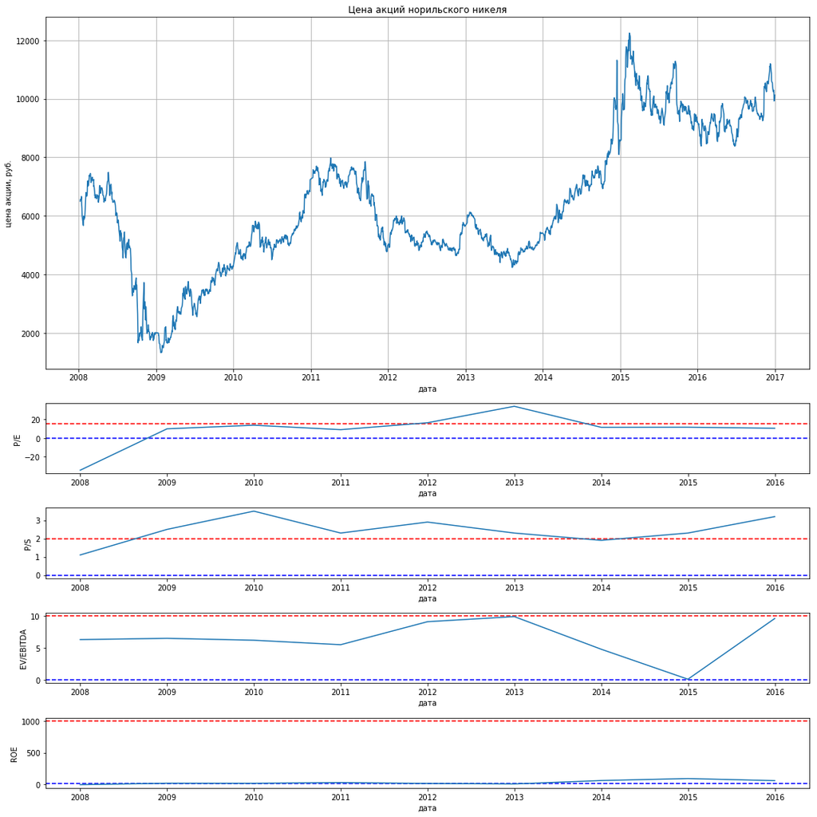

```python
fig = plt.figure(figsize=(15, 15))
gs = gridspec.GridSpec(mults.columns.shape[0] + 1, 1,
                  height_ratios=[5] + [1] * mults.columns.shape[0])
plt.subplot(gs[0])
ax.set_yticks(np.arange(2008, 2018))
plt.grid()
plt.title("Цена акций норильского никеля")
plt.ylabel("цена акции, руб.")
plt.xlabel("дата")
plt.plot(data["<HIGH>"])

for i, mult in enumerate(mults.columns, 1):
    plt.subplot(gs[i])
    plt.ylabel(mult)
    plt.xlabel("дата")
    plt.axhline(y=good_mults_cutoffs.loc["min", mult], color='b', linestyle='--')
    plt.axhline(y=good_mults_cutoffs.loc["max", mult], color='r', linestyle='--')
    plt.plot(mults[mult])

plt.tight_layout()
plt.savefig('results.pdf')
```

Синей линией обозначена отсечка для минимально хороших значений, красной -- для максимально хороших. Сведём результаты по годам в таблицу.

```python
for label in chosen_mults:
    mults[f"Хорошее значение {label}?"] = \
        np.bitwise_and(mults[label] <= good_mults_cutoffs.loc["max", label],
              mults[label] >= good_mults_cutoffs.loc["min", label])

mults["Хороших показателей"] = mults.apply(lambda x: sum(x[-5:-1].astype(int)), axis=1)
mults
```

|  | P/E | P/S | EV/EBITDA | ROE | Хорошее значение P/E? | Хорошее значение P/S? | Хорошее значение EV/EBITDA? | Хорошее значение ROE? | Хороших показателей |
| --- | --- | --- | --- | --- | --- | --- | --- | --- | --- |
| 2008 | -34.2 | 1.1 | 6.3 | -3.5 | False | True | True | False | 2 |
| 2009 | 9.8 | 2.5 | 6.5 | 19.9 | True | False | True | True | 3 |
| 2010 | 13.6 | 3.5 | 6.2 | 18.9 | True | False | True | True | 3 |
| 2011 | 8.9 | 2.3 | 5.5 | 29.6 | True | False | True | True | 3 |
| 2012 | 16.2 | 2.9 | 9.1 | 16.5 | False | False | True | True | 2 |
| 2013 | 33.7 | 2.3 | 9.9 | 8.3 | False | False | True | False | 1 |
| 2014 | 11.4 | 1.9 | 4.8 | 61.5 | True | True | True | True | 4 |
| 2015 | 11.5 | 2.3 | 0.1 | 92.6 | True | False | True | True | 3 |
| 2016 | 10.4 | 3.2 | 9.6 | 60.0 | True | False | True | True | 3 |